# Data Analytics Practicals 5 & 6 ~Airbnb many more useful tests & linear regression models

# Question 4.3

```r
summary(dublin$room_type)
```

```
## Entire home/apt    Private room     Shared room
##            4030            3733             166
```

```r
# 3
anova3 <- aov(reviews ~ room_type, data = dublin)

summary(anova3)
```

```
##               Df   Sum Sq Mean Sq F value   Pr(>F)
## room_type      2    36985   18492   12.69 3.16e-06 ***
## Residuals   7926 11554146    1458
## ---
## Signif. codes:  0 '***' 0.001 '**' 0.01 '*' 0.05 '.' 0.1 ' ' 1
```

```r
TukeyHSD(anova3)
```

```
##   Tukey multiple comparisons of means
##     95% family-wise confidence level
##
## Fit: aov(formula = reviews ~ room_type, data = dublin)
##
## $room_type
##                                    diff        lwr        upr     p adj
## Private room-Entire home/apt  -1.700235  -3.733337  0.3328664 0.1222332
## Shared room-Entire home/apt  -14.713474 -21.801691 -7.6252579 0.0000035
## Shared room-Private room     -13.013239 -20.112602 -5.9138764 0.0000521
```

# Question 4.4

```r
summary(dublin$overall_satisfaction)
```

```
##    Min. 1st Qu.  Median    Mean 3rd Qu.    Max.
##   0.000   0.000   4.500   3.099   5.000   5.000
```

```r
summary(amsterdam$overall_satisfaction)
```

```
##    Min. 1st Qu.  Median    Mean 3rd Qu.    Max.
##   0.000   0.000   4.500   3.301   5.000   5.000
```

```r
# 4
kruskal.test(overall_satisfaction ~ room_type, data = dublin)
```

```
##
##  Kruskal-Wallis rank sum test
##
## data:  overall_satisfaction by room_type
## Kruskal-Wallis chi-squared = 16.097, df = 2, p-value = 0.0003195
```

```r
kruskal.test(overall_satisfaction ~ room_type, data = amsterdam)
```

```
##
##  Kruskal-Wallis rank sum test
##
## data:  overall_satisfaction by room_type
## Kruskal-Wallis chi-squared = 16.877, df = 2, p-value = 0.0002164
```

```r
prop.test(x = c(3.099, 3.301), n = c(5,5), alternative = "two.sided", correct = TRUE)
```

```
##
##  2-sample test for equality of proportions with continuity correction
##
## data:  c(3.099, 3.301) out of c(5, 5)
## X-squared = 0, df = 1, p-value = 1
## alternative hypothesis: two.sided
## 95 percent confidence interval:
##  -0.6752761  0.5944761
## sample estimates:
## prop 1 prop 2
## 0.6198 0.6602
```

# Question 4.5

```r
summary(copenhagen$price)
```

```
##    Min. 1st Qu.  Median    Mean 3rd Qu.    Max.
##    10.0    77.0   105.0   118.4   144.0  5620.0
```

```r
summary(dublin$price)
```

```
##    Min. 1st Qu.  Median    Mean 3rd Qu.    Max.
##    12.0    60.0    95.0   124.8   150.0  1980.0
```

```r
summary(amsterdam$price)
```

```
##    Min. 1st Qu.  Median    Mean 3rd Qu.    Max.
##    12.0   108.0   144.0   166.6   192.0  6000.0
```

```r
summary(barcelona$price)
```

```
##    Min. 1st Qu.  Median    Mean 3rd Qu.    Max.
##    10.0    48.0    78.0   110.3   136.0  3606.0
```

```r
# 5
priceNotDifferttest1 <- t.test(copenhagen$price, dublin$price, var.equal = TRUE)
priceNotDifferttest1
```

```
##
##  Two Sample t-test
##
## data:  copenhagen$price and dublin$price
## t = -5.4834, df = 29228, p-value = 4.208e-08
## alternative hypothesis: true difference in means is not equal to 0
## 95 percent confidence interval:
##  -8.693195 -4.114902
## sample estimates:
## mean of x mean of y
##  118.3664  124.7705
```

```r
priceNotDifferttest2 <- t.test(dublin$price, amsterdam$price, var.equal = TRUE)
priceNotDifferttest2
```

```
##
##  Two Sample t-test
##
## data:  dublin$price and amsterdam$price
## t = -28.613, df = 26650, p-value < 2.2e-16
## alternative hypothesis: true difference in means is not equal to 0
## 95 percent confidence interval:
##  -44.69444 -38.96359
## sample estimates:
## mean of x mean of y
##  124.7705  166.5995
```

```r
priceNotDifferttest3 <- t.test(amsterdam$price, barcelona$price, var.equal = TRUE)
priceNotDifferttest3
```

```
##
##  Two Sample t-test
##
## data:  amsterdam$price and barcelona$price
## t = 47.978, df = 37559, p-value < 2.2e-16
## alternative hypothesis: true difference in means is not equal to 0
## 95 percent confidence interval:
##  54.02589 58.62810
## sample estimates:
## mean of x mean of y
##  166.5995  110.2725
```

# Question 4.6

```r
summary(paris$overall_satisfaction)
```

```
##    Min. 1st Qu.  Median    Mean 3rd Qu.    Max.
##   0.000   0.000   4.500   2.615   4.500   5.000
```

```r
summary(warsaw$overall_satisfaction)
```

```
##    Min. 1st Qu.  Median    Mean 3rd Qu.    Max.
##   0.000   0.000   4.500   2.678   5.000   5.000
```

```r
summary(amsterdam$overall_satisfaction)
```

```
##    Min. 1st Qu.  Median    Mean 3rd Qu.    Max.
##   0.000   0.000   4.500   3.301   5.000   5.000
```

```r
summary(iceland$overall_satisfaction)
```

```
##    Min. 1st Qu.  Median    Mean 3rd Qu.    Max.
##   0.000   0.000   4.500   3.381   5.000   5.000
```

```r
# 6
satisNotDifferttest1 <- t.test(paris$overall_satisfaction, warsaw$overall_satisfaction, var.equal = TRUE)
satisNotDifferttest1
```

```
##
##  Two Sample t-test
##
## data:  paris$overall_satisfaction and warsaw$overall_satisfaction
## t = -1.7718, df = 74749, p-value = 0.07644
## alternative hypothesis: true difference in means is not equal to 0
## 95 percent confidence interval:
##  -0.132218592  0.006668785
## sample estimates:
## mean of x mean of y
##  2.615104  2.677879
```

```r
satisNotDifferttest2 <- t.test(warsaw$overall_satisfaction, amsterdam$overall_satisfaction, var.equal = TRUE)
satisNotDifferttest2
```

```
##
##  Two Sample t-test
##
## data:  warsaw$overall_satisfaction and amsterdam$overall_satisfaction
## t = -16.847, df = 23314, p-value < 2.2e-16
## alternative hypothesis: true difference in means is not equal to 0
## 95 percent confidence interval:
##  -0.6957610 -0.5507342
## sample estimates:
## mean of x mean of y
##  2.677879  3.301127
```

```r
satisNotDifferttest3 <- t.test(amsterdam$overall_satisfaction, iceland$overall_satisfaction, var.equal = TRUE)
satisNotDifferttest3
```

```
##
##  Two Sample t-test
##
## data:  amsterdam$overall_satisfaction and iceland$overall_satisfaction
## t = -2.5813, df = 25838, p-value = 0.009849
## alternative hypothesis: true difference in means is not equal to 0
## 95 percent confidence interval:
##  -0.1400101 -0.0191523
## sample estimates:
## mean of x mean of y
##  3.301127  3.380708
```

## Correlation and ls linear regression analysis.

#we will work first on the protein-in-pregnancy data and on the US crime data that we saw in lectures.

```r
protein_preg<- read.csv("protein.csv", header=TRUE)
protein_preg
```

| Protein | Gestation |
| --- | --- |
| 0.38 | 11 |
| 0.58 | 12 |
| 0.51 | 13 |
| 0.38 | 15 |
| 0.58 | 17 |
| 0.67 | 18 |
| 0.84 | 19 |
| 0.56 | 21 |
| 0.78 | 22 |
| 0.86 | 25 |

[output cut: 9 more lines]

#always start with boxplots

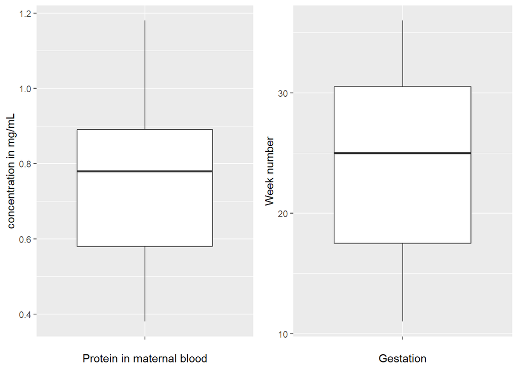

```r
proteinbox <- ggplot(protein_preg, aes(x="", y=Protein)) +
  geom_boxplot(outlier.colour="red", outlier.shape=1,
                outlier.size=2) +
ylab("concentration in mg/mL")+
  xlab("Protein in maternal blood")

gestationbox <- ggplot(protein_preg, aes(x="", y=Gestation)) +
  geom_boxplot(outlier.colour="blue", outlier.shape=1,
                outlier.size=2) +
ylab("Week number")+
  xlab("Gestation")

grid.arrange(proteinbox , gestationbox , ncol=2)
```

#we always check the data using a scatter plot.

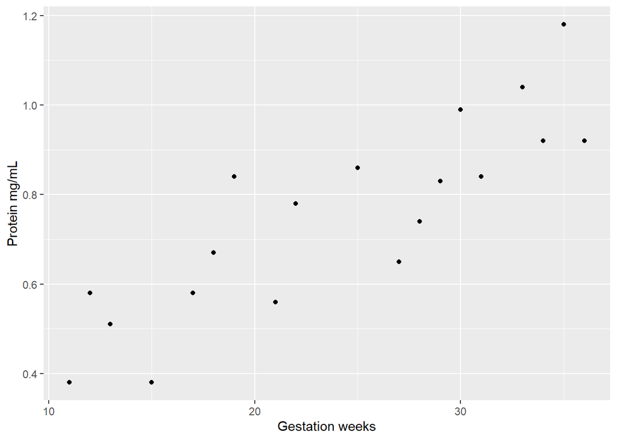

```r
scatter_protein <- ggplot(protein_preg, aes(x = Gestation, y = Protein)) +
    geom_point() +
  xlab("Gestation weeks") +
  ylab("Protein mg/mL")
scatter_protein
```

#here the data clearly suggest a positive linear relationship.

#now we run a simple Peasron corrleation analysis.

```r
protein_preg %>%
  summarize(N = n(), r = cor(Gestation, Protein))
```

| N | r |
| --- | --- |
| 19 | 0.8595157 |

#The results of also suggest a strong positive linear relationship (r=0.86) between the variables.

#Now we run a simple least sqaures linear regression with an interest in modelling the relations between gestation week and protein concentration in mother’s blood.

#Note the reponsse variable is protein concentration and it is modelled as the y variable.

```r
protein_model <- lm(formula= Protein ~ Gestation, data=protein_preg)
summary(protein_model)
```

```
##
## Call:
## lm(formula = Protein ~ Gestation, data = protein_preg)
##
## Residuals:
##      Min       1Q   Median       3Q      Max
## -0.16853 -0.08720 -0.01009  0.08578  0.20422
##
## Coefficients:
##             Estimate Std. Error t value Pr(>|t|)
## (Intercept) 0.201738   0.083363   2.420    0.027 *
## Gestation   0.022844   0.003295   6.934 2.42e-06 ***
## ---
## Signif. codes:  0 '***' 0.001 '**' 0.01 '*' 0.05 '.' 0.1 ' ' 1
##
## Residual standard error: 0.1151 on 17 degrees of freedom
## Multiple R-squared:  0.7388, Adjusted R-squared:  0.7234
## F-statistic: 48.08 on 1 and 17 DF,  p-value: 2.416e-06
```

#a lot of information is provided in the output.

#Key information is:

#1.ModelR2 (adjusted) is 0.723.

#2.F-statistic p-value is significant at 2.4 x 10-6.

#3.Intercept estimate is 0.20174 and its t-value and associated p-value (p=0.027) indicate that it is different from 0.

#4.Gestation estimate is 0.02284 and its t-value and associated p-value (p=2.4x10-6) indicate that it is different from 0.

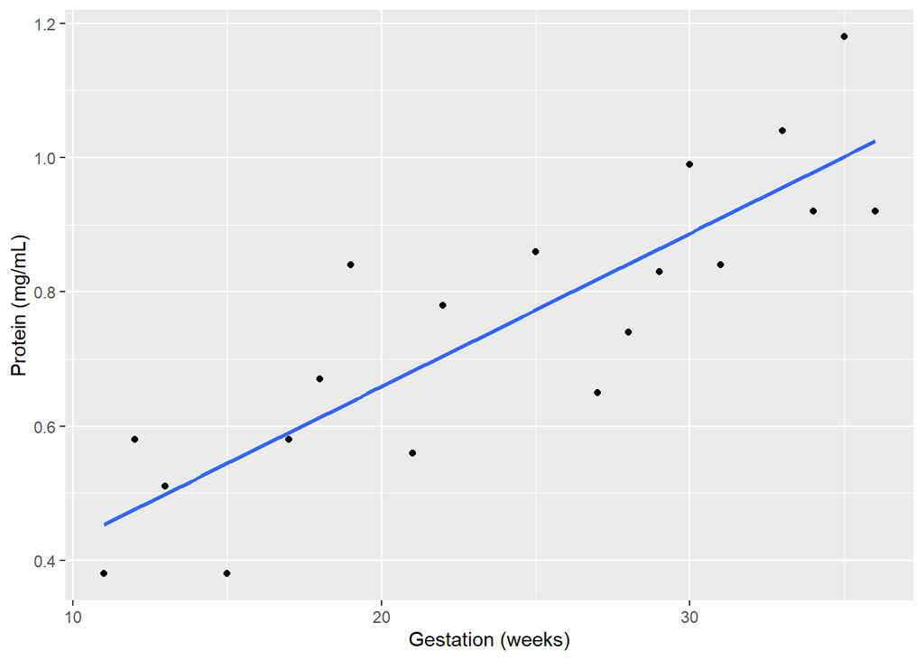

```r
scatter_protein2 <- ggplot(protein_preg, aes(x = Gestation, y = Protein)) +
    geom_point() +
   geom_smooth(method = "lm", se = FALSE) +  #adds ls regression line
    xlab("Gestation (weeks)") +
  ylab("Protein (mg/mL)")
scatter_protein2
```

## Exercise 5.

#Using some of the code above, create the following linear regression models from the crime.csv dataset.(some code is given to get you started)

#1. Crime = Bo + B1(Dropout) + errors.

#2. Crime = Bo + B1(Police) + errors.

#3. Crime = Bo + B1(Prison) + errors.

#4. Crime = Bo + B1(Poverty) + errors.

#check the lecture slides for the precise meanings of these variables.

#You should comment on these models outise the code chunks, base comments on the R2 values and the overall model’s F-statistic associated p-value.

#make sure to plot the data.

#can you build an better predictive model based on a multiple linear regression model, i.e. one that explains more of the variation in crime rate than the single variable prediction models above?

#e.g. Crime = Bo + B1(Dropout)+ B2(X2) + B3(X3)…

#be sure to adhere to the key assumptions of multiple linear regression when choosing your model.

```r
UScrime<- read.csv("crime.csv", header=TRUE)
UScrime
```

| C1.T | Crime | Police | Prison | Poverty | Dropout |
| --- | --- | --- | --- | --- | --- |
| Florida | 8358 | 382 | 369 | 15.3 | 14.3 |
| Texas | 7058 | 260 | 381 | 17.8 | 12.9 |
| Arizona | 7029 | 366 | 415 | 15.1 | 14.4 |
| California | 6679 | 454 | 355 | 15.8 | 14.2 |
| Louisiana | 6546 | 256 | 505 | 24.2 | 12.5 |
| NewMexico | 6434 | 293 | 205 | 21.0 | 11.7 |
| Georgia | 6405 | 267 | 382 | 17.8 | 14.1 |
| Maryland | 6225 | 348 | 385 | 11.6 | 10.9 |
| Nevada | 6204 | 454 | 457 | 14.4 | 15.2 |
| Washington | 6173 | 327 | 197 | 11.0 | 10.6 |

[output cut: 40 more lines]

```r
UScrime_for_martix <- UScrime[, c(2,3,4,5,6)]
head(UScrime_for_martix)
```

|  | Crime | Police | Prison | Poverty | Dropout |
| --- | --- | --- | --- | --- | --- |
| 1 | 8358 | 382 | 369 | 15.3 | 14.3 |
| 2 | 7058 | 260 | 381 | 17.8 | 12.9 |
| 3 | 7029 | 366 | 415 | 15.1 | 14.4 |
| 4 | 6679 | 454 | 355 | 15.8 | 14.2 |
| 5 | 6546 | 256 | 505 | 24.2 | 12.5 |
| 6 | 6434 | 293 | 205 | 21.0 | 11.7 |

```r
cormatrix <- round(cor(UScrime_for_martix),2)
head(cormatrix)
```

```
##         Crime Police Prison Poverty Dropout
## Crime    1.00   0.55   0.56    0.16    0.56
## Police   0.55   1.00   0.29   -0.30    0.26
## Prison   0.56   0.29   1.00    0.40    0.58
## Poverty  0.16  -0.30   0.40    1.00    0.49
## Dropout  0.56   0.26   0.58    0.49    1.00
```

#1. Crime = Bo + B1(Dropout) + errors.

```r
UScrime %>%
  summarize(N = n(), r = cor(Crime, Dropout))
```

| N | r |
| --- | --- |
| 50 | 0.5559609 |

```r
dropout_model <- lm(formula= Crime ~ Dropout, data=UScrime)
summary(dropout_model)
```

```
##
## Call:
## lm(formula = Crime ~ Dropout, data = UScrime)
##
## Residuals:
##     Min      1Q  Median      3Q     Max
## -2657.7  -698.0   158.8   653.3  2132.3
##
## Coefficients:
##             Estimate Std. Error t value Pr(>|t|)
## (Intercept)   2196.5      640.0   3.432  0.00124 **
## Dropout        281.8       60.8   4.634 2.77e-05 ***
## ---
## Signif. codes:  0 '***' 0.001 '**' 0.01 '*' 0.05 '.' 0.1 ' ' 1
##
## Residual standard error: 1024 on 48 degrees of freedom
## Multiple R-squared:  0.3091, Adjusted R-squared:  0.2947
## F-statistic: 21.47 on 1 and 48 DF,  p-value: 2.77e-05
```

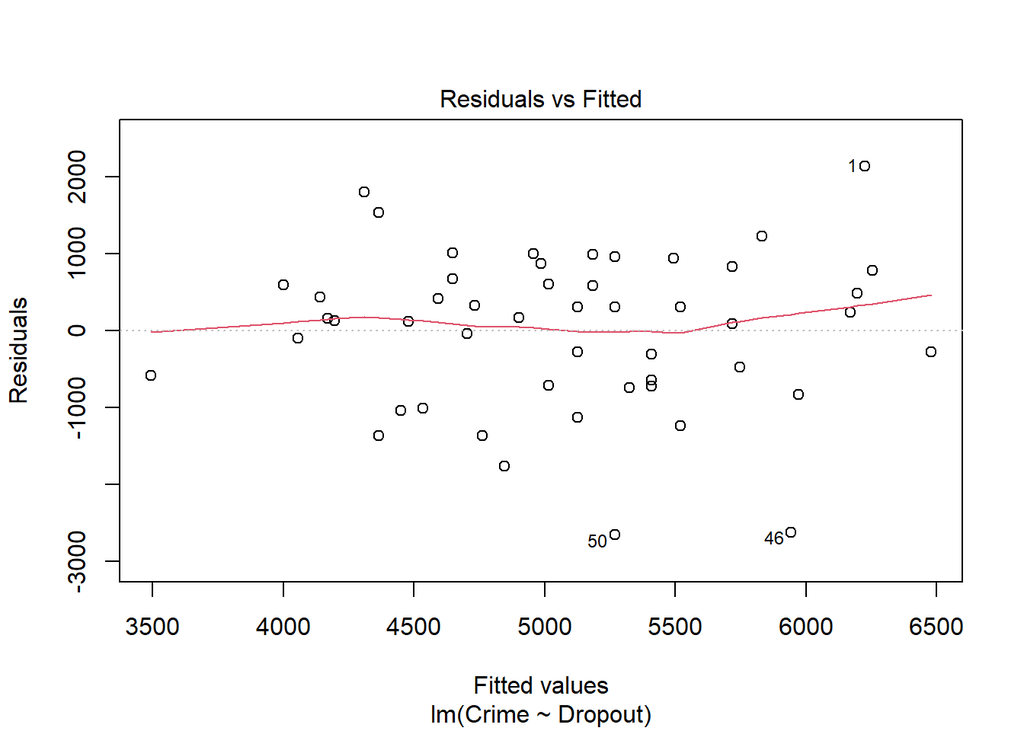

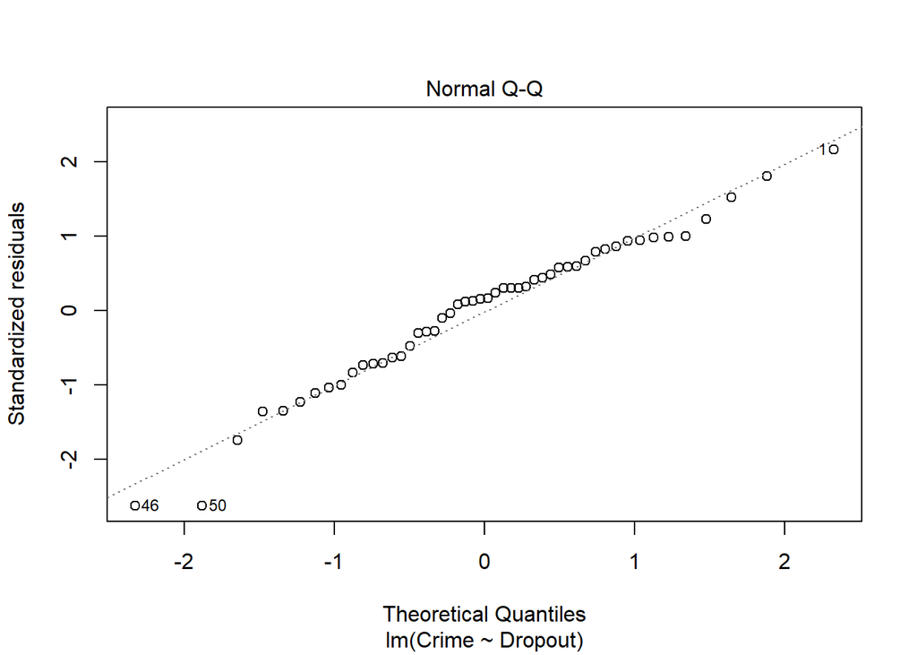

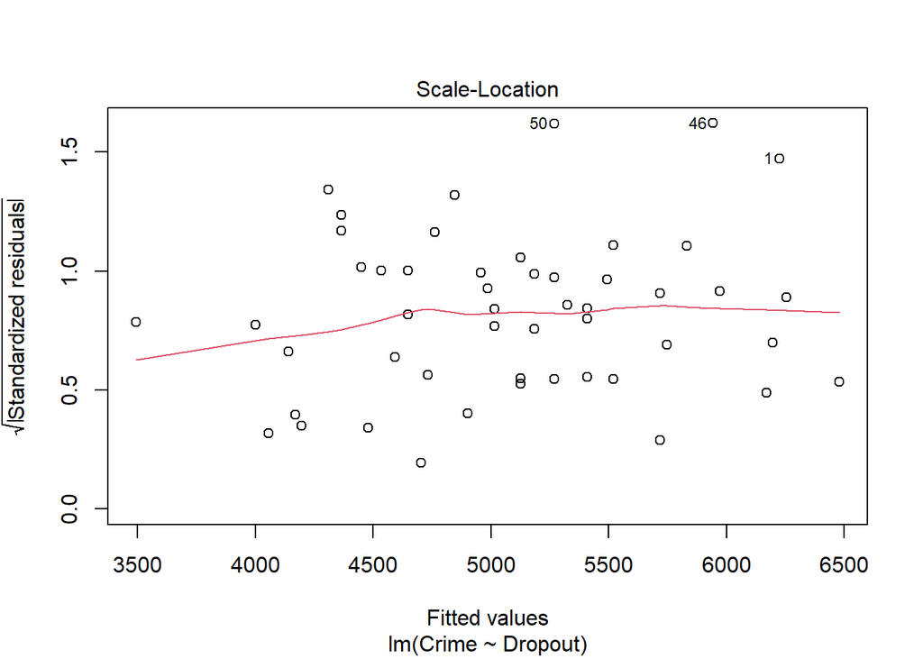

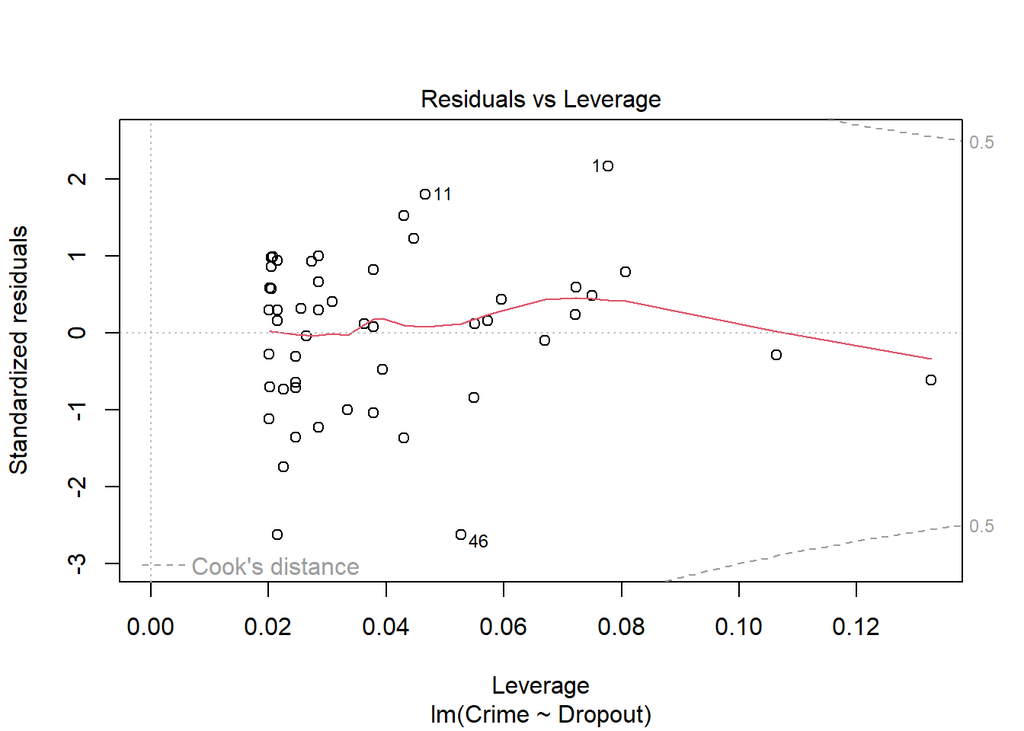

```r
plot(dropout_model)
```

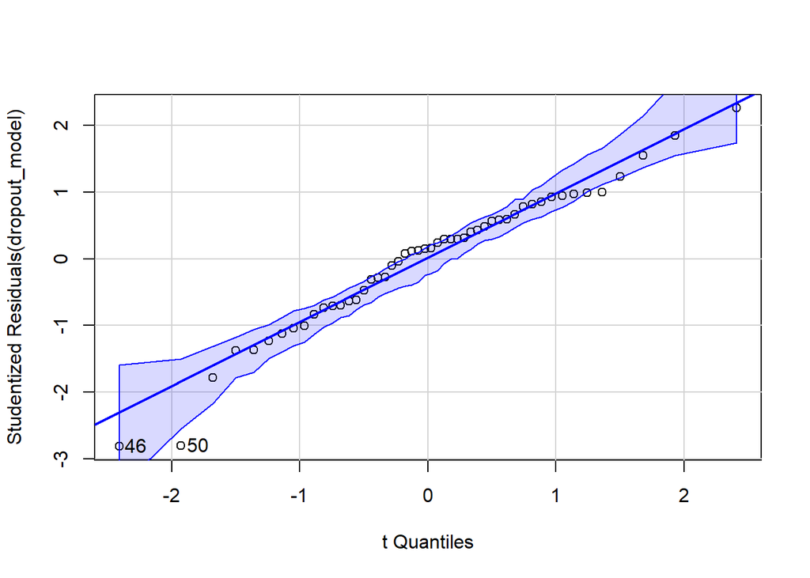

```
## [1] 46 50
```

```r
qqPlot(dropout_model)
```

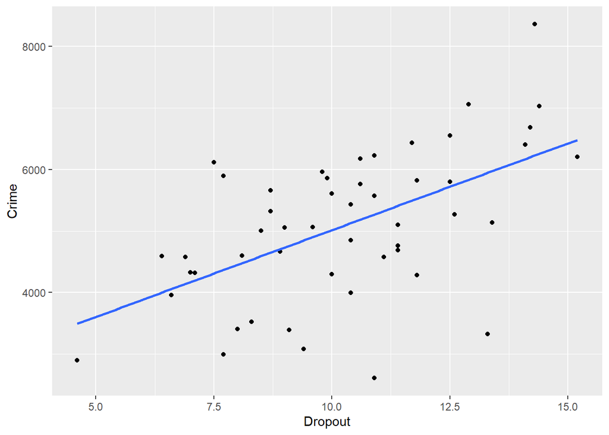

```r
dropoutgg <- ggplot(UScrime, aes(x = Dropout, y = Crime)) +
    geom_point() +
   geom_smooth(method = "lm", se = FALSE) +  #adds ls regression line
    xlab("Dropout") +
  ylab("Crime")
dropoutgg
```

#2. Crime = Bo + B1(Police) + errors.

```r
UScrime %>%
  summarize(N = n(), r = cor(Crime, Police))
```

| N | r |
| --- | --- |
| 50 | 0.5467634 |

```r
police_model <- lm(formula= Crime ~ Police, data=UScrime)
summary(police_model)
```

```
##
## Call:
## lm(formula = Crime ~ Police, data = UScrime)
##
## Residuals:
##      Min       1Q   Median       3Q      Max
## -1882.95  -746.08    20.81   671.88  2530.33
##
## Coefficients:
##             Estimate Std. Error t value Pr(>|t|)
## (Intercept) 3251.485    430.752   7.548 1.07e-09 ***
## Police         6.744      1.491   4.524 3.99e-05 ***
## ---
## Signif. codes:  0 '***' 0.001 '**' 0.01 '*' 0.05 '.' 0.1 ' ' 1
##
## Residual standard error: 1031 on 48 degrees of freedom
## Multiple R-squared:  0.299,  Adjusted R-squared:  0.2843
## F-statistic: 20.47 on 1 and 48 DF,  p-value: 3.988e-05
```

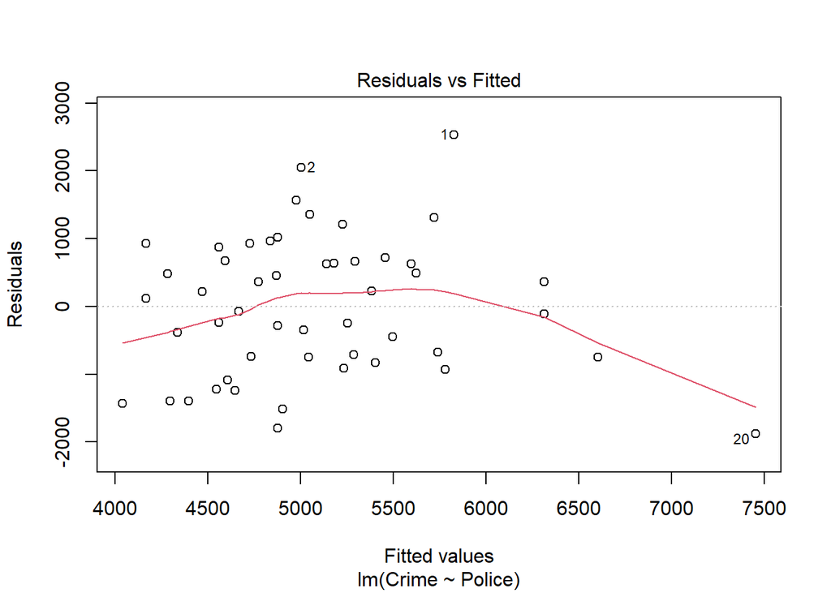

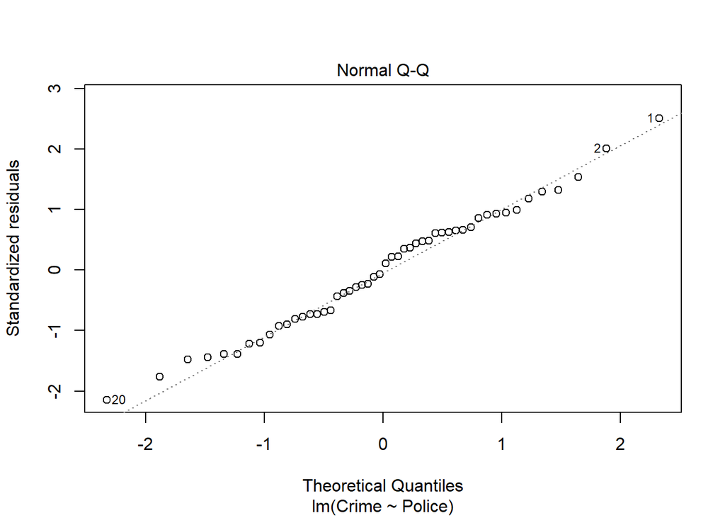

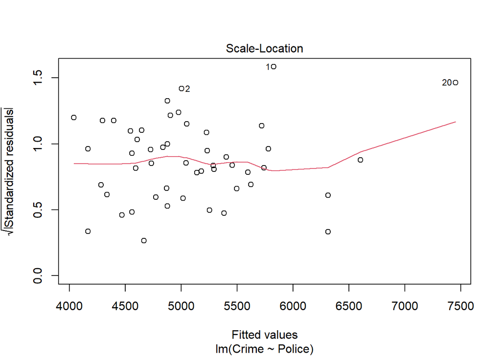

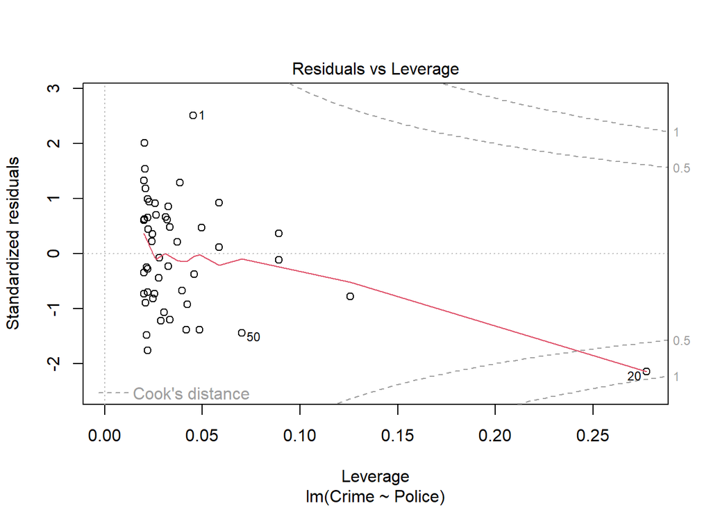

```r
plot(police_model)
```

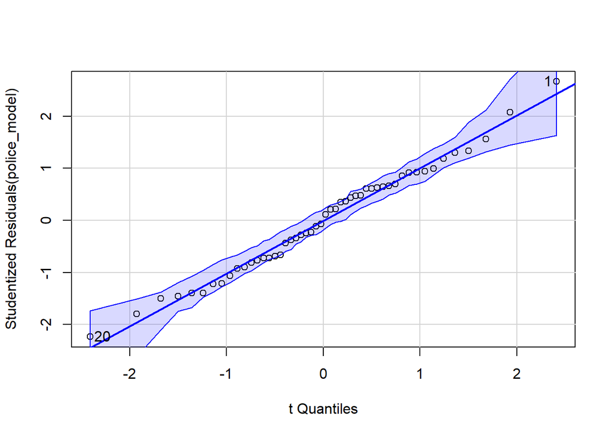

```
## [1]  1 20
```

```r
qqPlot(police_model)
```

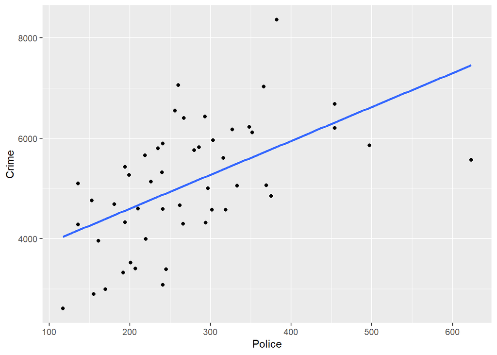

```r
policegg <- ggplot(UScrime, aes(x = Police, y = Crime)) +
    geom_point() +
   geom_smooth(method = "lm", se = FALSE) +  #adds ls regression line
    xlab("Police") +
  ylab("Crime")
policegg
```

#3. Crime = Bo + B1(Prison) + errors.

```r
UScrime %>%
  summarize(N = n(), r = cor(Crime, Prison))
```

| N | r |
| --- | --- |
| 50 | 0.5628836 |

```r
prison_model <- lm(formula= Crime ~ Prison, data=UScrime)
summary(prison_model)
```

```
##
## Call:
## lm(formula = Crime ~ Prison, data = UScrime)
##
## Residuals:
##      Min       1Q   Median       3Q      Max
## -1808.28  -735.74   -89.56   595.59  2708.46
##
## Coefficients:
##             Estimate Std. Error t value Pr(>|t|)
## (Intercept) 3574.856    351.000  10.185 1.39e-13 ***
## Prison         5.622      1.192   4.718 2.09e-05 ***
## ---
## Signif. codes:  0 '***' 0.001 '**' 0.01 '*' 0.05 '.' 0.1 ' ' 1
##
## Residual standard error: 1018 on 48 degrees of freedom
## Multiple R-squared:  0.3168, Adjusted R-squared:  0.3026
## F-statistic: 22.26 on 1 and 48 DF,  p-value: 2.09e-05
```

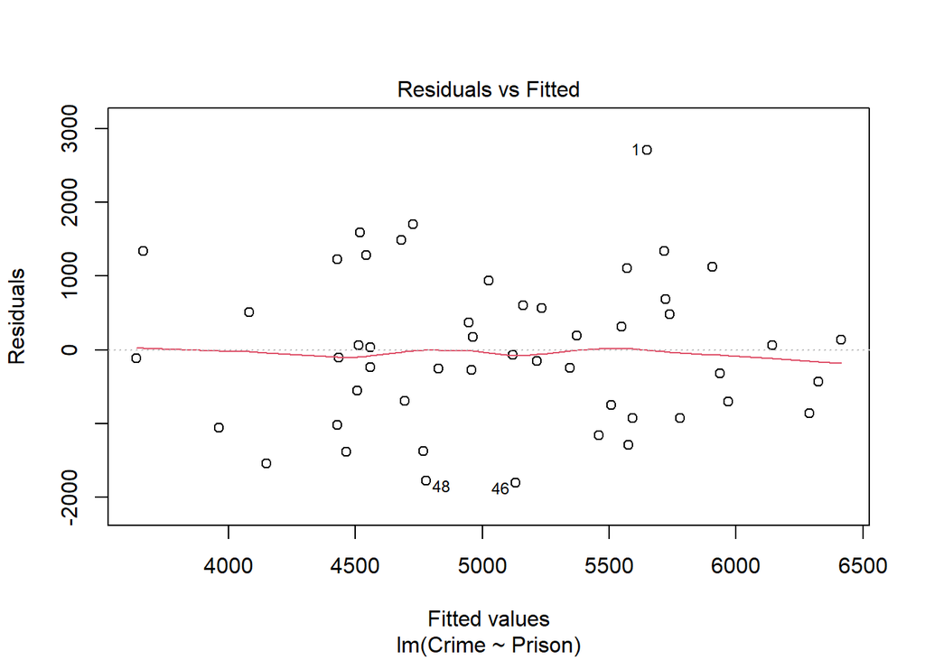

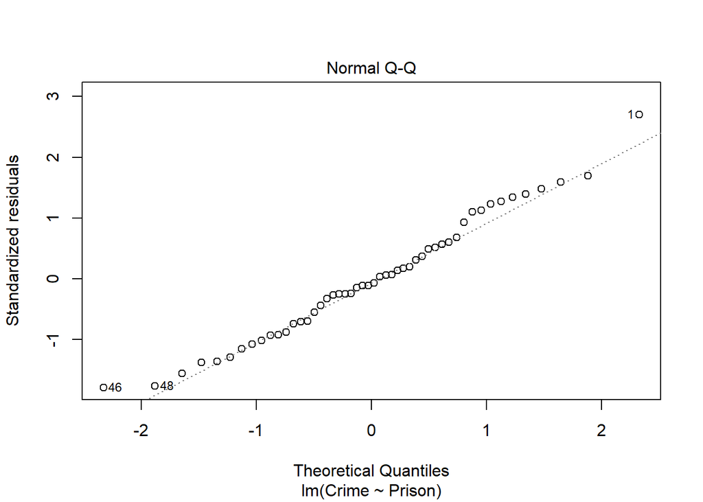

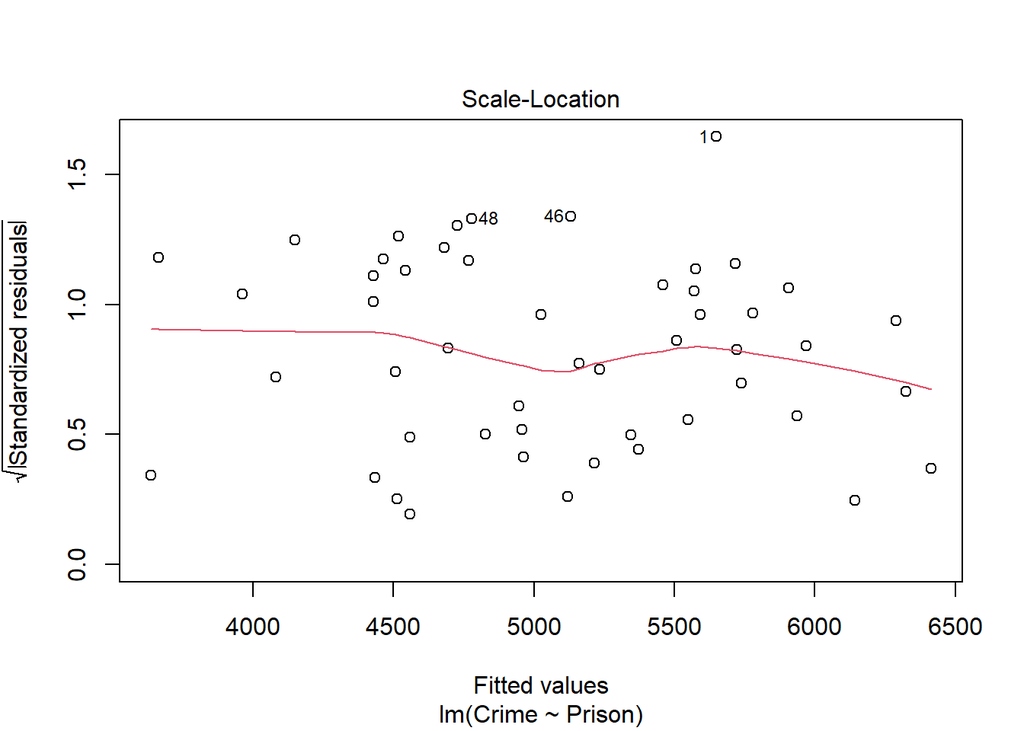

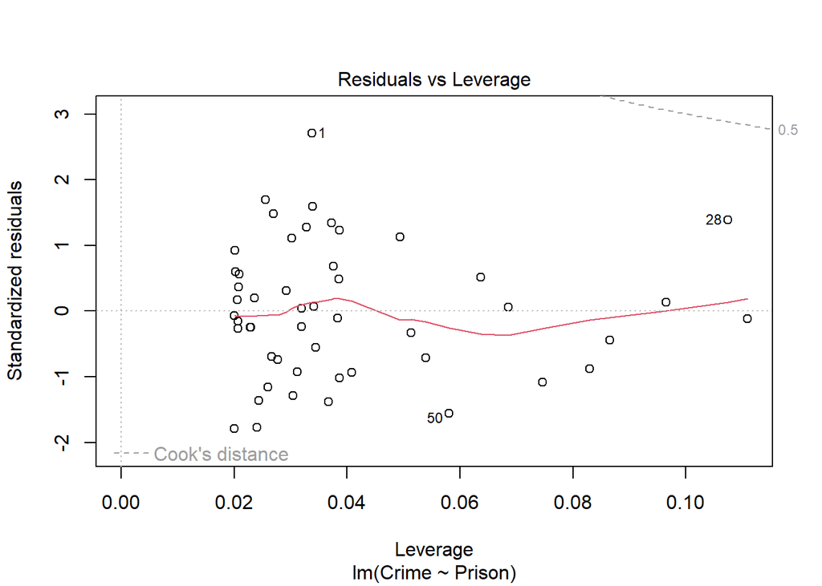

```r
plot(prison_model)
```

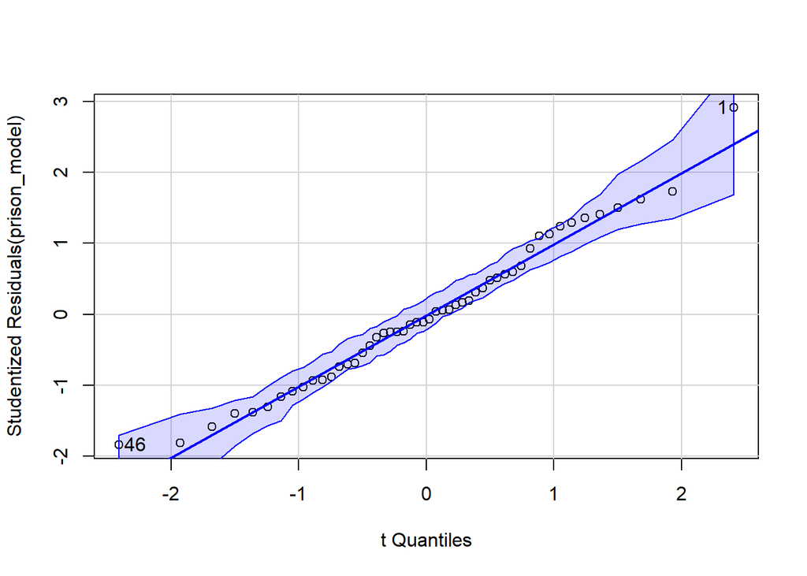

```
## [1]  1 46
```

```r
qqPlot(prison_model)
```

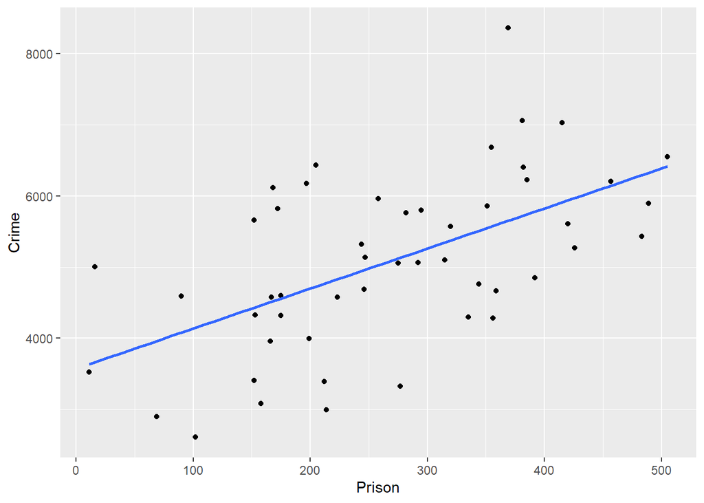

```r
prisongg <- ggplot(UScrime, aes(x = Prison, y = Crime)) +
    geom_point() +
   geom_smooth(method = "lm", se = FALSE) +  #adds ls regression line
    xlab("Prison") +
  ylab("Crime")
prisongg
```

#4. Crime = Bo + B1(Poverty) + errors.

```r
UScrime %>%
  summarize(N = n(), r = cor(Crime, Poverty))
```

| N | r |
| --- | --- |
| 50 | 0.1611488 |

```r
poverty_model <- lm(formula= Crime ~ Poverty, data=UScrime)
summary(poverty_model)
```

```
##
## Call:
## lm(formula = Crime ~ Poverty, data = UScrime)
##
## Residuals:
##     Min      1Q  Median      3Q     Max
## -2883.5  -580.9    88.9   846.6  3205.1
##
## Coefficients:
##             Estimate Std. Error t value Pr(>|t|)
## (Intercept)  4408.47     622.40   7.083 5.49e-09 ***
## Poverty        48.65      43.01   1.131    0.264
## ---
## Signif. codes:  0 '***' 0.001 '**' 0.01 '*' 0.05 '.' 0.1 ' ' 1
##
## Residual standard error: 1216 on 48 degrees of freedom
## Multiple R-squared:  0.02597,    Adjusted R-squared:  0.005677
## F-statistic:  1.28 on 1 and 48 DF,  p-value: 0.2636
```

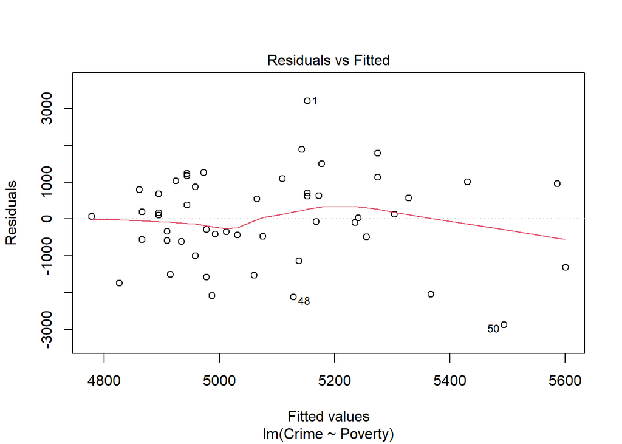

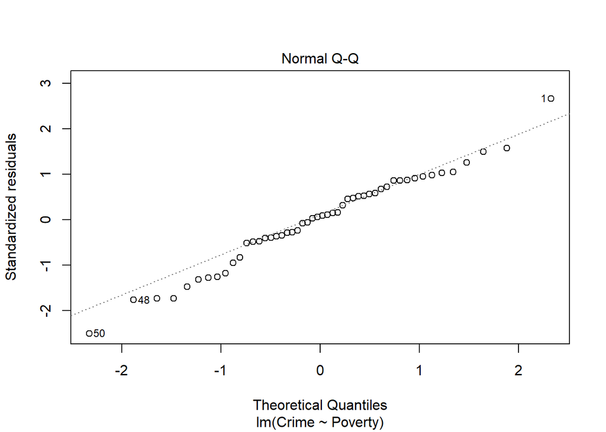

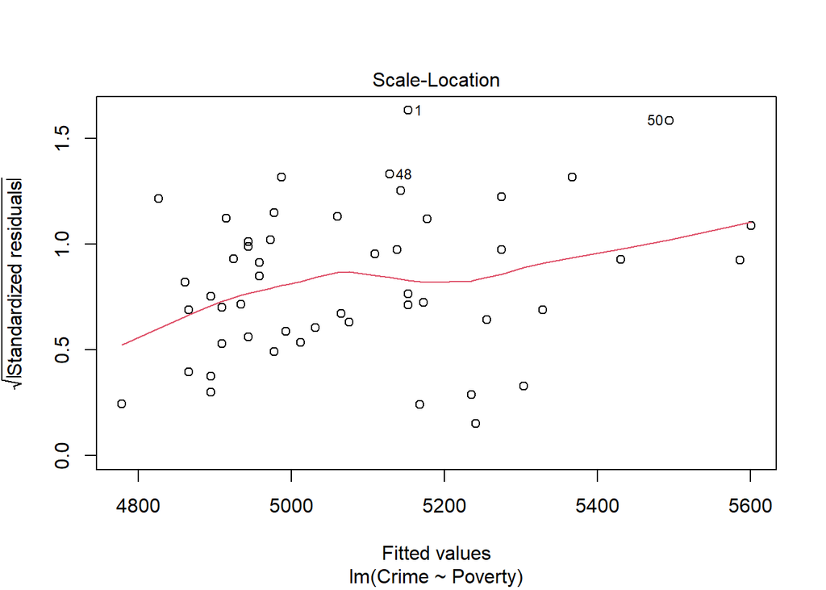

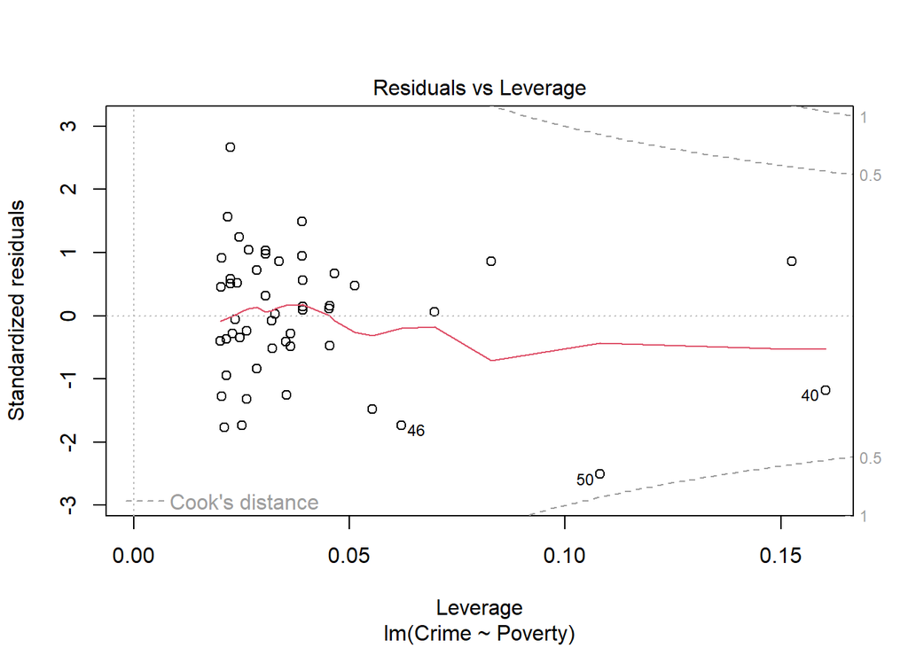

```r
plot(poverty_model)
```

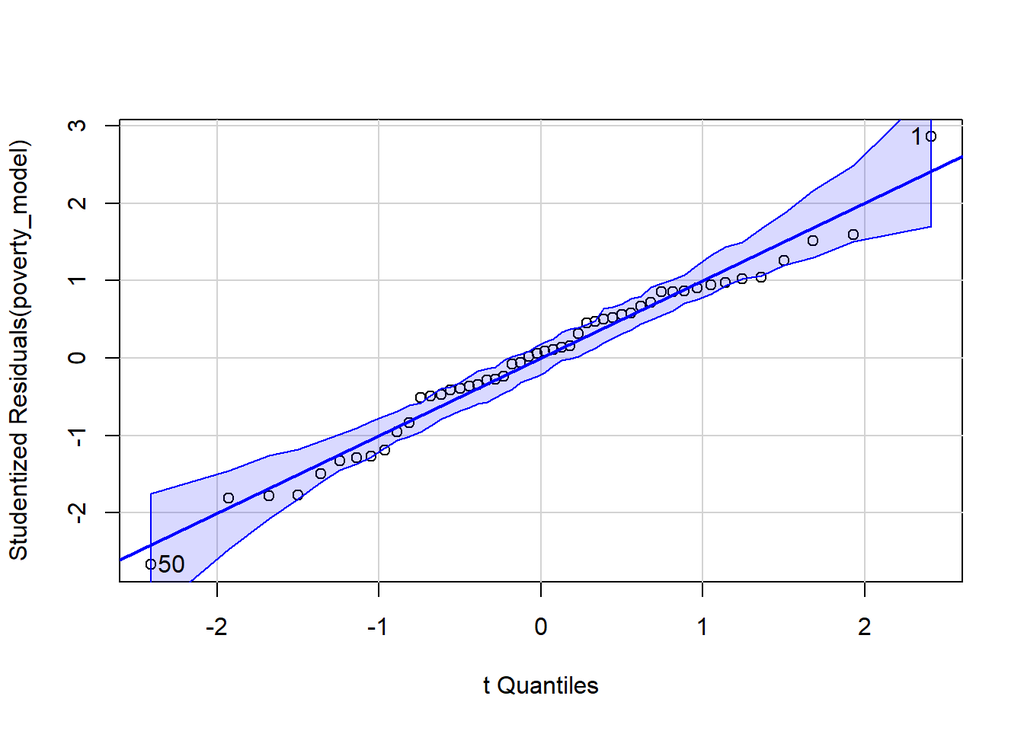

```
## [1]  1 50
```

```r
qqPlot(poverty_model)
```

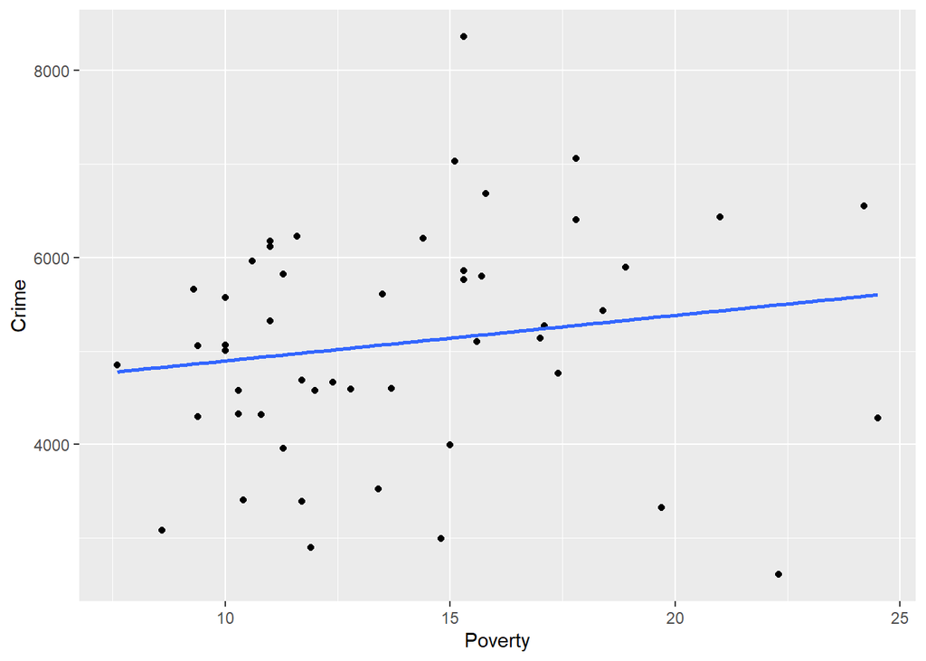

```r
povertygg <- ggplot(UScrime, aes(x = Poverty, y = Crime)) +
    geom_point() +
   geom_smooth(method = "lm", se = FALSE) +  #adds ls regression line
    xlab("Poverty") +
  ylab("Crime")
povertygg
```

#for extra marks, can you create a heat map figure based on this correlation matrix?

#see: http://www.sthda.com/english/wiki/ggplot2-quick-correlation-matrix-heatmap-r-software-and-data-visualization